# Employee Attrition and performance prediction (HR Analytics)

## Description:

### This project aims to predict employee attrition in an organization using supervised machine learning techniques. Attrition, or employee turnover, is a critical issue in Human Resource (HR) analytics, and early prediction helps in strategic decision-making for employee retention. A real-world HR dataset was used, containing various employee attributes such as age, gender, job satisfaction, monthly income, distance from home, and more. The target variable is Attrition, classified as Yes or No.

## Import Libraries

```python
import numpy as np
import pandas as pd
import matplotlib.pyplot as plt
import seaborn as sns
from sklearn.model_selection import train_test_split, GridSearchCV
from sklearn.preprocessing import StandardScaler
from sklearn.preprocessing import LabelEncoder
from sklearn.metrics import classification_report, roc_auc_score, confusion_matrix
from sklearn.linear_model import LogisticRegression
from sklearn.ensemble import RandomForestClassifier
from xgboost import XGBClassifier
from sklearn.svm import SVC
from sklearn.neighbors import KNeighborsClassifier
from sklearn.ensemble import GradientBoostingClassifier
from imblearn.over_sampling import SMOTE
from sklearn.compose import ColumnTransformer
from sklearn.metrics import accuracy_score, confusion_matrix
```

## Load Dataset

```python
data= pd.read_csv('IBM-HR-Employee-Attrition-Performance.csv')
```

## Exploratory Data analysis

```python
data.head()
```

|  | Age | Attrition | BusinessTravel | DailyRate | Department | DistanceFromHome | Education | EducationField | EmployeeCount | EmployeeNumber | ... | RelationshipSatisfaction | StandardHours | StockOptionLevel | TotalWorkingYears | TrainingTimesLastYear | WorkLifeBalance | YearsAtCompany | YearsInCurrentRole | YearsSinceLastPromotion | YearsWithCurrManager |
| --- | --- | --- | --- | --- | --- | --- | --- | --- | --- | --- | --- | --- | --- | --- | --- | --- | --- | --- | --- | --- | --- |
| 0 | 41 | Yes | Travel_Rarely | 1102 | Sales | 1 | 2 | Life Sciences | 1 | 1 | ... | 1 | 80 | 0 | 8 | 0 | 1 | 6 | 4 | 0 | 5 |
| 1 | 49 | No | Travel_Frequently | 279 | Research & Development | 8 | 1 | Life Sciences | 1 | 2 | ... | 4 | 80 | 1 | 10 | 3 | 3 | 10 | 7 | 1 | 7 |
| 2 | 37 | Yes | Travel_Rarely | 1373 | Research & Development | 2 | 2 | Other | 1 | 4 | ... | 2 | 80 | 0 | 7 | 3 | 3 | 0 | 0 | 0 | 0 |
| 3 | 33 | No | Travel_Frequently | 1392 | Research & Development | 3 | 4 | Life Sciences | 1 | 5 | ... | 3 | 80 | 0 | 8 | 3 | 3 | 8 | 7 | 3 | 0 |
| 4 | 27 | No | Travel_Rarely | 591 | Research & Development | 2 | 1 | Medical | 1 | 7 | ... | 4 | 80 | 1 | 6 | 3 | 3 | 2 | 2 | 2 | 2 |

5 rows × 35 columns

```python
data.info()
```

```
<class 'pandas.core.frame.DataFrame'>
RangeIndex: 1470 entries, 0 to 1469
Data columns (total 35 columns):
 #   Column                    Non-Null Count  Dtype
---  ------                    --------------  -----
 0   Age                       1470 non-null   int64
 1   Attrition                 1470 non-null   object
 2   BusinessTravel            1470 non-null   object
 3   DailyRate                 1470 non-null   int64
 4   Department                1470 non-null   object
 5   DistanceFromHome          1470 non-null   int64
 6   Education                 1470 non-null   int64
 7   EducationField            1470 non-null   object
 8   EmployeeCount             1470 non-null   int64
 9   EmployeeNumber            1470 non-null   int64
```

[output cut: 27 more lines]

```python
data.isnull().sum()
```

```
Age                         0
Attrition                   0
BusinessTravel              0
DailyRate                   0
Department                  0
DistanceFromHome            0
Education                   0
EducationField              0
EmployeeCount               0
EmployeeNumber              0
EnvironmentSatisfaction     0
Gender                      0
HourlyRate                  0
JobInvolvement              0
JobLevel                    0
JobRole                     0
JobSatisfaction             0
MaritalStatus               0
MonthlyIncome               0
MonthlyRate                 0
NumCompaniesWorked          0
Over18                      0
OverTime                    0
PercentSalaryHike           0
PerformanceRating           0
RelationshipSatisfaction    0
StandardHours               0
StockOptionLevel            0
TotalWorkingYears           0
TrainingTimesLastYear       0
WorkLifeBalance             0
YearsAtCompany              0
YearsInCurrentRole          0
YearsSinceLastPromotion     0
YearsWithCurrManager        0
dtype: int64
```

```python
print(data.columns.tolist())
```

[output not shown]

```python
data.describe()
```

|  | Age | DailyRate | DistanceFromHome | Education | EmployeeCount | EmployeeNumber | EnvironmentSatisfaction | HourlyRate | JobInvolvement | JobLevel | ... | RelationshipSatisfaction | StandardHours | StockOptionLevel | TotalWorkingYears | TrainingTimesLastYear | WorkLifeBalance | YearsAtCompany | YearsInCurrentRole | YearsSinceLastPromotion | YearsWithCurrManager |
| --- | --- | --- | --- | --- | --- | --- | --- | --- | --- | --- | --- | --- | --- | --- | --- | --- | --- | --- | --- | --- | --- |
| count | 1470.000000 | 1470.000000 | 1470.000000 | 1470.000000 | 1470.0 | 1470.000000 | 1470.000000 | 1470.000000 | 1470.000000 | 1470.000000 | ... | 1470.000000 | 1470.0 | 1470.000000 | 1470.000000 | 1470.000000 | 1470.000000 | 1470.000000 | 1470.000000 | 1470.000000 | 1470.000000 |
| mean | 36.923810 | 802.485714 | 9.192517 | 2.912925 | 1.0 | 1024.865306 | 2.721769 | 65.891156 | 2.729932 | 2.063946 | ... | 2.712245 | 80.0 | 0.793878 | 11.279592 | 2.799320 | 2.761224 | 7.008163 | 4.229252 | 2.187755 | 4.123129 |
| std | 9.135373 | 403.509100 | 8.106864 | 1.024165 | 0.0 | 602.024335 | 1.093082 | 20.329428 | 0.711561 | 1.106940 | ... | 1.081209 | 0.0 | 0.852077 | 7.780782 | 1.289271 | 0.706476 | 6.126525 | 3.623137 | 3.222430 | 3.568136 |
| min | 18.000000 | 102.000000 | 1.000000 | 1.000000 | 1.0 | 1.000000 | 1.000000 | 30.000000 | 1.000000 | 1.000000 | ... | 1.000000 | 80.0 | 0.000000 | 0.000000 | 0.000000 | 1.000000 | 0.000000 | 0.000000 | 0.000000 | 0.000000 |
| 25% | 30.000000 | 465.000000 | 2.000000 | 2.000000 | 1.0 | 491.250000 | 2.000000 | 48.000000 | 2.000000 | 1.000000 | ... | 2.000000 | 80.0 | 0.000000 | 6.000000 | 2.000000 | 2.000000 | 3.000000 | 2.000000 | 0.000000 | 2.000000 |
| 50% | 36.000000 | 802.000000 | 7.000000 | 3.000000 | 1.0 | 1020.500000 | 3.000000 | 66.000000 | 3.000000 | 2.000000 | ... | 3.000000 | 80.0 | 1.000000 | 10.000000 | 3.000000 | 3.000000 | 5.000000 | 3.000000 | 1.000000 | 3.000000 |
| 75% | 43.000000 | 1157.000000 | 14.000000 | 4.000000 | 1.0 | 1555.750000 | 4.000000 | 83.750000 | 3.000000 | 3.000000 | ... | 4.000000 | 80.0 | 1.000000 | 15.000000 | 3.000000 | 3.000000 | 9.000000 | 7.000000 | 3.000000 | 7.000000 |
| max | 60.000000 | 1499.000000 | 29.000000 | 5.000000 | 1.0 | 2068.000000 | 4.000000 | 100.000000 | 4.000000 | 5.000000 | ... | 4.000000 | 80.0 | 3.000000 | 40.000000 | 6.000000 | 4.000000 | 40.000000 | 18.000000 | 15.000000 | 17.000000 |

8 rows × 26 columns

```python
data.nunique()
```

```
Age                           43
Attrition                      2
BusinessTravel                 3
DailyRate                    886
Department                     3
DistanceFromHome              29
Education                      5
EducationField                 6
EmployeeCount                  1
EmployeeNumber              1470
EnvironmentSatisfaction        4
Gender                         2
HourlyRate                    71
JobInvolvement                 4
JobLevel                       5
JobRole                        9
JobSatisfaction                4
MaritalStatus                  3
MonthlyIncome               1349
MonthlyRate                 1427
NumCompaniesWorked            10
Over18                         1
OverTime                       2
PercentSalaryHike             15
PerformanceRating              2
RelationshipSatisfaction       4
StandardHours                  1
StockOptionLevel               4
TotalWorkingYears             40
TrainingTimesLastYear          7
WorkLifeBalance                4
YearsAtCompany                37
YearsInCurrentRole            19
YearsSinceLastPromotion       16
YearsWithCurrManager          18
dtype: int64
```

## Visualization of the data

```python
data['Attrition'].value_counts(normalize=False)
```

```
Attrition
No     1233
Yes     237
Name: count, dtype: int64
```

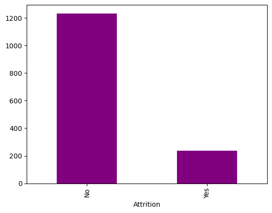

```python
data['Attrition'].value_counts().plot(kind='bar',color='purple')
```

### From the above graph we conclude that the proportion of Attrition is small

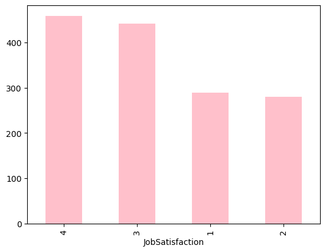

```python
data['JobSatisfaction'].value_counts().plot(kind='bar',color='pink')
```

### From above graph we can conclude that the satisfaction level is high among the individuals

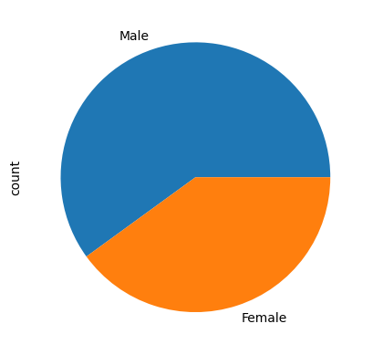

```python
data['Gender'].value_counts().plot(kind='pie')
```

### Conclusion= number of females workers is less than the number of males workers

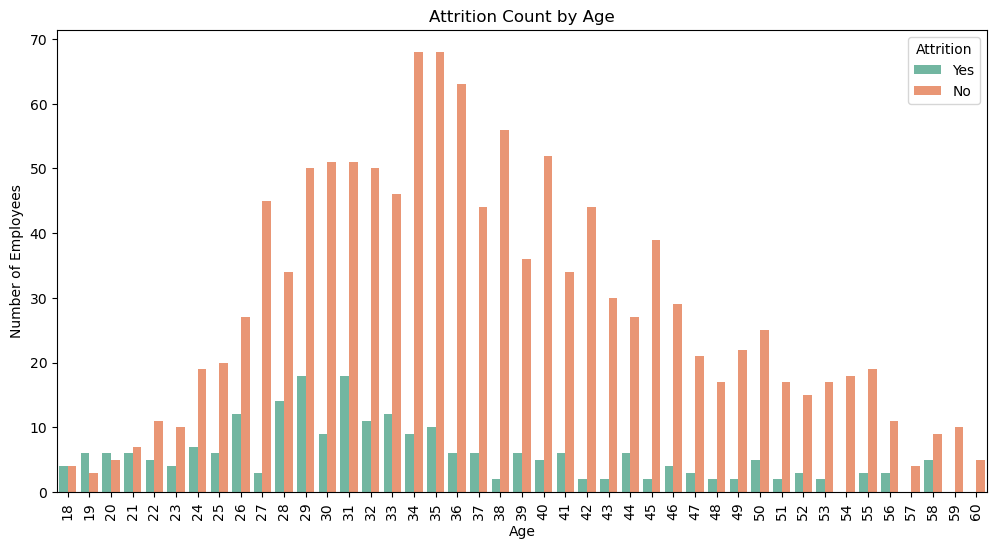

```python
plt.figure(figsize=(12, 6))
sns.countplot(x='Age', hue='Attrition', data=data, palette='Set2')
plt.title('Attrition Count by Age')
plt.xlabel('Age')
plt.ylabel('Number of Employees')
plt.xticks(rotation=90)
plt.show()
```

### Conclusion = As we can see from above graph that number of Attrition is higher among age intervals 28-31 of employees

```python
data['Attrition_Flag'] = data['Attrition'].map({'Yes': 1, 'No': 0})
department_attrition = data.groupby('Department')['Attrition_Flag'].mean().sort_values(ascending=False)
print(department_attrition)
```

```
Department
Sales                     0.206278
Human Resources           0.190476
Research & Development    0.138398
Name: Attrition_Flag, dtype: float64
```

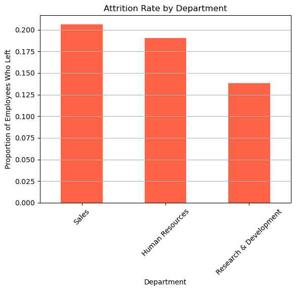

```python
department_attrition.plot(kind='bar', color='tomato')
plt.title('Attrition Rate by Department')
plt.ylabel('Proportion of Employees Who Left')
plt.xticks(rotation=45)
plt.grid(axis='y')
plt.show()
```

### Conclusion = As we can see from above graph that proportion of Attrition is higher in sales department

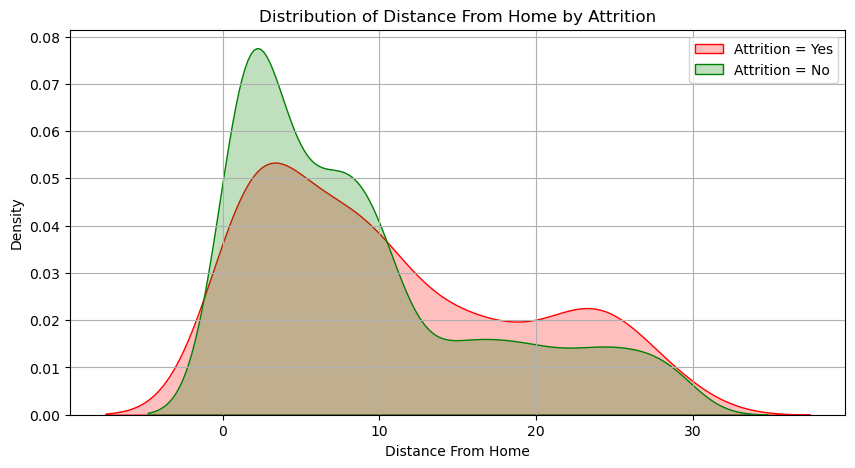

```python
plt.figure(figsize=(10, 5))
sns.kdeplot(data=data[data['Attrition'] == 'Yes']['DistanceFromHome'], label='Attrition = Yes', fill=True, color='red')
sns.kdeplot(data=data[data['Attrition'] == 'No']['DistanceFromHome'], label='Attrition = No', fill=True, color='green')
plt.title('Distribution of Distance From Home by Attrition')
plt.xlabel('Distance From Home')
plt.legend()
plt.grid()
plt.show()
```

### Conclusion = Both groups have a peak between 1–10 km, indicating that most employees live close to work, regardless of attrition. At Longer Distances (15–30+) There is a higher density of employees who left compared to those who stayed.This implies:Employees with longer commutes are more likely to leave. There is a weak but visible correlation: as distance from home increases, attrition (employee leaving) also increases slightly.

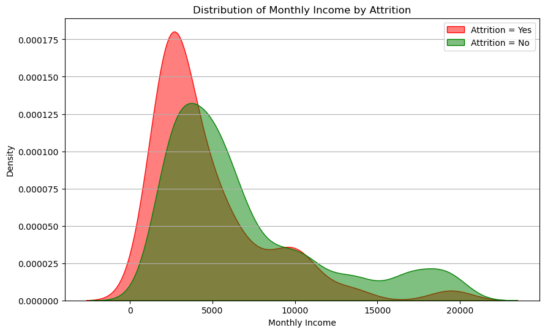

```python
plt.figure(figsize=(10,6))
sns.kdeplot(data=data[data['Attrition'] == 'Yes']['MonthlyIncome'],label='Attrition = Yes',fill=True,color='red',alpha=0.5)
sns.kdeplot(data=data[data['Attrition'] == 'No']['MonthlyIncome'],label='Attrition = No',fill=True,color='green',alpha=0.5)
plt.title('Distribution of Monthly Income by Attrition')
plt.xlabel('Monthly Income')
plt.ylabel('Density')
plt.legend()
plt.grid(axis='y')
plt.show()
```

### Conclusion = There is a negative relationship between income and attrition. Lower-income employees are more likely to leave, possibly due to dissatisfaction or better external opportunities, while higher-income employees tend to stay longer.

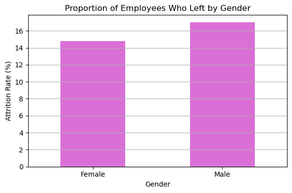

```python
data['Attrition_Flag'] = data['Attrition'].apply(lambda x: 1 if x == 'Yes' else 0)
gender_attrition = data.groupby('Gender')['Attrition_Flag'].mean() * 100
plt.figure(figsize=(6,4))
gender_attrition.plot(kind='bar', color='orchid')
plt.title('Proportion of Employees Who Left by Gender')
plt.ylabel('Attrition Rate (%)')
plt.xlabel('Gender')
plt.xticks(rotation=0)
plt.grid(axis='y')
plt.tight_layout()
plt.show()
```

### Conclusion = Proportion of Employees who left is higher for males as compared to females

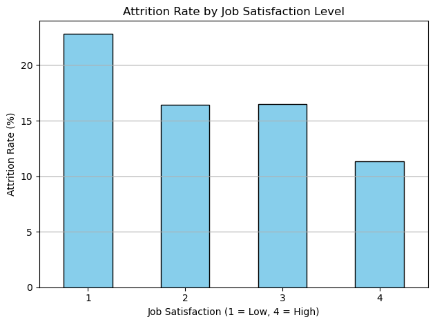

```python
job_satisfaction_attrition = data.groupby('JobSatisfaction')['Attrition_Flag'].mean() * 100
job_satisfaction_attrition.plot(kind='bar', color='skyblue', edgecolor='black')
plt.title('Attrition Rate by Job Satisfaction Level')
plt.xlabel('Job Satisfaction (1 = Low, 4 = High)')
plt.ylabel('Attrition Rate (%)')
plt.xticks(rotation=0)
plt.grid(axis='y')
plt.tight_layout()
plt.show()
```

### Conclusion = Attrition Rate is higher for the employees having job satisfaction level 1 as compared to other levels

## Feature Engineering

```python
data.drop(columns=['EmployeeCount','Over18','StandardHours','EmployeeNumber'] , axis=1 ,inplace=True)
```

```python
x=data.drop(columns=['Attrition'])
y=data['Attrition']
```

```python
categoricals = x.select_dtypes(include='object').columns
x = pd.get_dummies(x, columns=categoricals, drop_first=True)
```

```python
scaler=StandardScaler()
x=scaler.fit_transform(x)
```

```python
LE=LabelEncoder()
y=LE.fit_transform(y)
```

## Train Test Split

```python
x_train,x_test,y_train,y_test = train_test_split(x,y, test_size=0.2)
```

```python
y_train.shape
```

```
(1176,)
```

```python
x_train.shape
```

```
(1176, 44)
```

## Model Training and Evaluation

## Logistic Regression

```python
lr = LogisticRegression(max_iter=500, class_weight='balanced')
lr.fit(x_train, y_train)
y_pred = lr.predict(x_test)
from sklearn.model_selection import cross_val_score
np.mean(cross_val_score(LogisticRegression(),x, y,cv=10,scoring='accuracy'))
```

```
0.883673469387755
```

### Random Forest

```python
rf = RandomForestClassifier(class_weight='balanced')
rf.fit(x_train, y_train)
y_pred = rf.predict(x_test)
from sklearn.model_selection import cross_val_score
np.mean(cross_val_score(RandomForestClassifier(),x, y,cv=10,scoring='accuracy'))
```

```
0.8591836734693878
```

### XGBoost

```python
# XGBoost
xgb = XGBClassifier( eval_metric='logloss')
xgb.fit(x_train, y_train)
y_pred = xgb.predict(x_test)
from sklearn.model_selection import cross_val_score
np.mean(cross_val_score(XGBClassifier(eval_metric='logloss'),x, y,cv=10,scoring='accuracy'))
```

```
0.8619047619047618
```

### SVC

```python
svm = SVC(probability=True, class_weight='balanced')
svm.fit(x_train, y_train)
y_pred = svm.predict(x_test)
from sklearn.model_selection import cross_val_score
np.mean(cross_val_score(SVC(),x, y,cv=10,scoring='accuracy'))
```

```
0.8680272108843538
```

### KNeighbors

```python
# KNN
scores=[]
for i in range(1,16):
    knn = KNeighborsClassifier(n_neighbors=i)
    knn.fit(x_train, y_train)
    y_pred = knn.predict(x_test)
    scores.append(accuracy_score(y_test,y_pred))
```

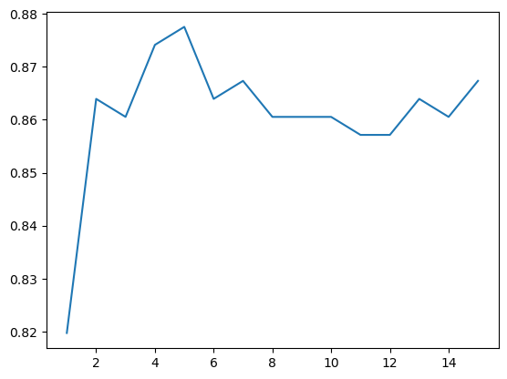

```python
plt.plot(range(1,16),scores)
```

```python
knn = KNeighborsClassifier(n_neighbors=5)
knn.fit(x_train, y_train)
y_pred = knn.predict(x_test)
accuracy_score(y_test,y_pred)
```

```
0.8775510204081632
```

### Stacking

```python
estimators = [
    ('rf', RandomForestClassifier(n_estimators=10, random_state =42)),
    ('knn', KNeighborsClassifier(n_neighbors=10)),
    ('gbdt',GradientBoostingClassifier())
]
```

```python
from sklearn.ensemble import StackingClassifier
clf= StackingClassifier(
    estimators=estimators,
    final_estimator= LogisticRegression(),
    cv=10
)
```

```python
clf.fit(x_train,y_train)
```

```
StackingClassifier(cv=10,
                   estimators=[('rf',
                                RandomForestClassifier(n_estimators=10,
                                                       random_state=42)),
                               ('knn', KNeighborsClassifier(n_neighbors=10)),
                               ('gbdt', GradientBoostingClassifier())],
                   final_estimator=LogisticRegression())
```

```python
y_pred = clf.predict(x_test)
accuracy_score(y_test,y_pred)
```

```
0.8877551020408163
```

### How many Clusters can we make ?

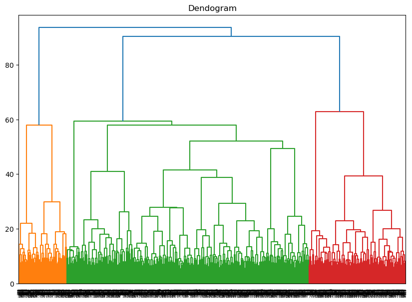

```python
import scipy.cluster.hierarchy as shc
plt.figure(figsize=(10,7))
plt.title('Dendogram')
dend = shc.dendrogram(shc.linkage(x,method = 'ward'))
```

### Can we reduce this dataset into a few dimensions ?

```python
from sklearn.decomposition import PCA
from sklearn.neighbors import KNeighborsClassifier
for i in range(1,31):
    pca=PCA(n_components=i)
    x_train_trf=pca.fit_transform(x_train)
    x_test_trf=pca.transform(x_test)
    knn= KNeighborsClassifier()
    knn.fit(x_train_trf,y_train)
    y_pred=knn.predict(x_test_trf)
    print(i,accuracy_score(y_test,y_pred))
```

```
1 0.8299319727891157
2 0.8197278911564626
3 0.8401360544217688
4 0.8401360544217688
5 0.8503401360544217
6 0.8469387755102041
7 0.8401360544217688
8 0.8435374149659864
9 0.8401360544217688
10 0.8435374149659864
11 0.8503401360544217
12 0.8537414965986394
13 0.8571428571428571
14 0.8605442176870748
15 0.8537414965986394
16 0.8571428571428571
17 0.8435374149659864
18 0.8401360544217688
19 0.8469387755102041
20 0.8469387755102041
21 0.8435374149659864
22 0.8435374149659864
23 0.8469387755102041
24 0.8605442176870748
25 0.8537414965986394
26 0.8537414965986394
27 0.8639455782312925
28 0.8605442176870748
29 0.8639455782312925
30 0.8775510204081632
```

### Visualization of dataset into 3d Dimentions

```python
pca=PCA(n_components=3)
x_train_trf=pca.fit_transform(x_train)
x_test_trf=pca.transform(x_test)
x_train_trf.shape
import plotly.express as px
y_train_trf= y_train.astype(str)
fig=px.scatter_3d(x=x_train_trf[:,0],y=x_train_trf[:,1],z=x_train_trf[:,2],color=y_train_trf)
fig.update_layout(width=1000,height=1000)
fig.show()
```

[interactive chart not shown]